# Non-Linear Regression

Nick Climaco

2024-04-07

# KJ : Applied Predictive Modeling

## Load Data

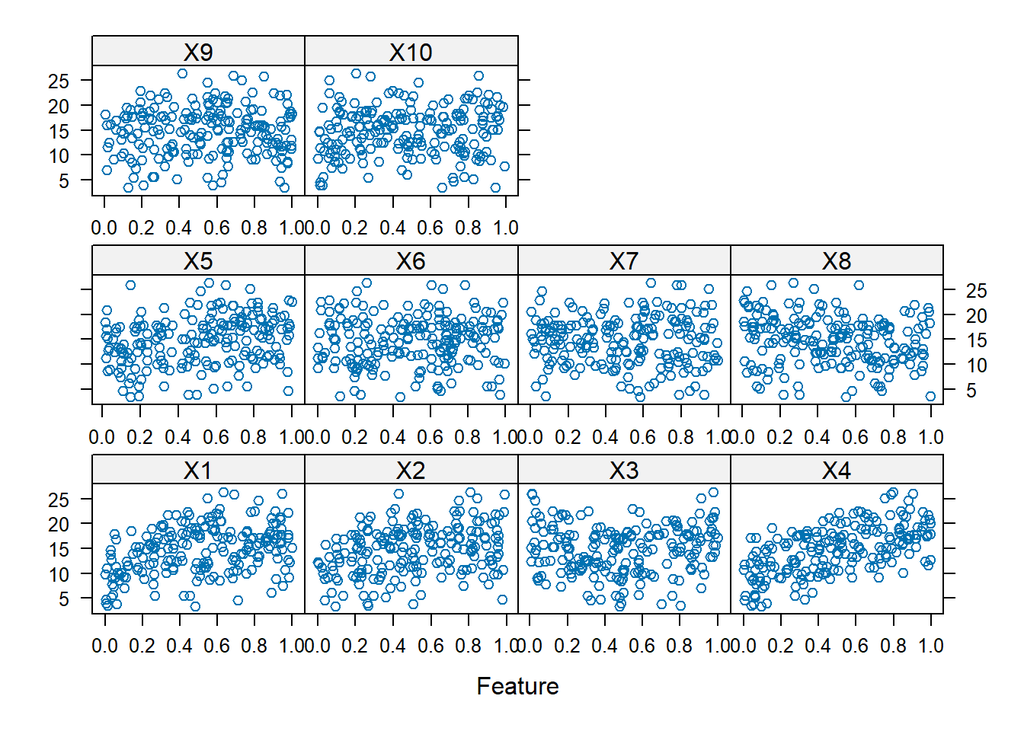

```r
set.seed(1998)

trainingData <- mlbench.friedman1(200, sd = 1)

trainingData$x <- data.frame(trainingData$x)

featurePlot(trainingData$x, trainingData$y)
```

```r
testData <- mlbench.friedman1(5000,sd=1)

testData$x <- data.frame(testData$x)
```

## Exercise 7.2

Friedman (1991) introduced several benchmark data sets create by simulation. One of these simulations used the following nonlinear equation to create data:

$$y = 10 sin(πx_1x_2) + 20(x_3 − 0.5)^2 + 10x_4 + 5x_5 + N(0, σ^2)$$
where the x values are random variables uniformly distributed between [0, 1] (there are also 5 other non-informative variables also created in the simulation).

Which models appear to give the best performance?

Does MARS select the informative predictors (those named X1–X5)?

### Solution

#### MARS Model

```r
set.seed(1998)
mars_cv = expand.grid(degree=1:3,nprune = seq(2,50, by = 2))
mars_model = train(x = trainingData$x,
                   y = trainingData$y,
                   method = 'earth',
                   preProc = c('center', 'scale'),
                   tuneGrid = mars_cv,
                   trControl = trainControl(method = 'cv')
                   )

mars_predicts <- predict(mars_model, newsdata=testData$x)
```

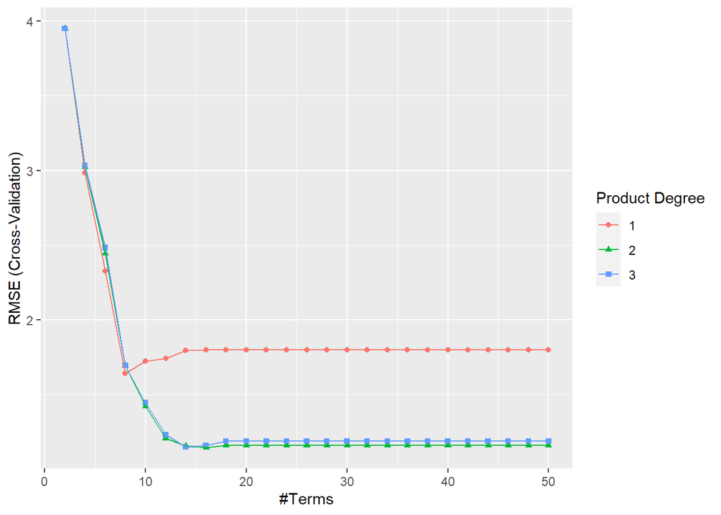

```r
ggplot(mars_model)
```

```r
postResample(pred = mars_predicts, obs = testData$y)
```

```
##     RMSE Rsquared      MAE
## 6.925904       NA 5.555462
```

```r
varImp(mars_model)
```

```
## earth variable importance
##
##    Overall
## X4  100.00
## X1   59.67
## X2   38.61
## X5   16.16
## X3    0.00
```

#### SVM Model

```r
set.seed(1998)

svm_model <- train(x=trainingData$x, y=trainingData$y,
                   method = 'svmRadial',
                   preProc = c('center', 'scale'),
                   tuneLength = 10,
                   trControl = trainControl(method = 'cv'))
```

```r
svm_preds<- predict(svm_model, newdata = testData$x)
```

```r
postResample(pred = svm_preds, obs = testData$y)
```

```
##      RMSE  Rsquared       MAE
## 2.0399868 0.8309463 1.5746414
```

The best performing model is SMV Radial with the lowest RMSE and MAE, and the best fit of the data.

## Exercise 7.5

Exercise 6.3 describes data for a chemical manufacturing process. Use the same data imputation, data splitting, and pre-processing steps as before and train several nonlinear regression models.

### Solution

```r
library(AppliedPredictiveModeling)
data(ChemicalManufacturingProcess)
```

```r
X <- ChemicalManufacturingProcess |> select(-Yield)
y <- ChemicalManufacturingProcess |> select(Yield)
```

```r
trainIndex <- createDataPartition(y = y$Yield,
                                  p = 0.7,
                                  list = FALSE)
X_train <- X[trainIndex,]
y_train <- y[trainIndex,]

X_test <- X[-trainIndex,]
y_test <- y[-trainIndex,]
```

```r
# preprocess the data with transformation, scaling and imputations
preprocessing <- preProcess(X_train, method = c('BoxCox', 'center','scale','medianImpute'))

X_train_pp <- predict(preprocessing, X_train)
X_test_pp <- predict(preprocessing, X_test)
```

```r
# remove near zero variance columns
nearZero <- nearZeroVar(X_train_pp)
X_train_pp <- X_train_pp[-nearZero]
X_test_pp <- X_test_pp[-nearZero]
```

```r
# reduce multicollinearity
trainCorr <- cor(X_train_pp)
highCorr <- findCorrelation(trainCorr)
X_train_pp <- X_train_pp[-highCorr]
X_test_pp <- X_test_pp[-highCorr]
```

```r
# MARS Model
set.seed(1998)

mars_cv = expand.grid(degree=1:2,nprune = seq(2,10, by = 1))
mars_chem_model = train(x = X_train_pp,
                   y = y_train,
                   method = 'earth',
                   tuneGrid = mars_cv,
                   trControl = trainControl(method = 'cv')
                   )

mars_chem_predicts <- predict(mars_chem_model, newdata=X_test_pp)
```

```r
mars_chem_model
```

```
## Multivariate Adaptive Regression Spline
##
## 124 samples
##  48 predictor
##
## No pre-processing
## Resampling: Cross-Validated (10 fold)
## Summary of sample sizes: 112, 111, 111, 112, 111, 112, ...
## Resampling results across tuning parameters:
##
##   degree  nprune  RMSE      Rsquared   MAE
##   1        2      1.267538  0.5202269  1.0161346
##   1        3      1.215079  0.5481186  0.9570787
##   1        4      1.277011  0.5029596  0.9769205
##   1        5      1.317722  0.4789021  1.0328969
##   1        6      1.319547  0.4811377  1.0283504
##   1        7      1.337300  0.4865113  1.0502068
##   1        8      1.355023  0.4960831  1.0475274
##   1        9      1.378557  0.4974912  1.0682226
##   1       10      1.431452  0.4665347  1.0960447
##   2        2      1.267538  0.5202269  1.0161346
##   2        3      1.217394  0.5318867  0.9845325
##   2        4      1.254805  0.5333443  1.0184827
##   2        5      1.293300  0.5163055  1.0591166
##   2        6      1.315796  0.5232028  1.0680937
##   2        7      1.405806  0.4818350  1.1165823
##   2        8      1.391416  0.4906644  1.0898523
##   2        9      1.401566  0.4838838  1.0956448
##   2       10      1.420293  0.4804594  1.1100097
##
## RMSE was used to select the optimal model using the smallest value.
## The final values used for the model were nprune = 3 and degree = 1.
```

```r
postResample(mars_chem_predicts, obs = y_test)
```

```
##     RMSE Rsquared      MAE
## 1.485711 0.439396 1.081886
```

```r
# SVM Model

set.seed(1998)

svm_chem_model <- train(x=X_train_pp, y=y_train,
                   method = 'svmRadial',
                   tuneLength = 10,
                   trControl = trainControl(method = 'cv'))
svm_chem_predict <- predict(svm_chem_model, newdata = X_test_pp)
```

```r
svm_chem_model
```

```
## Support Vector Machines with Radial Basis Function Kernel
##
## 124 samples
##  48 predictor
##
## No pre-processing
## Resampling: Cross-Validated (10 fold)
## Summary of sample sizes: 112, 111, 111, 112, 111, 112, ...
## Resampling results across tuning parameters:
##
##   C       RMSE      Rsquared   MAE
##     0.25  1.340549  0.5187688  1.0825681
##     0.50  1.251814  0.5419342  1.0100475
##     1.00  1.196368  0.5650672  0.9537518
##     2.00  1.184907  0.5610127  0.9447656
##     4.00  1.184083  0.5575021  0.9500758
##     8.00  1.163888  0.5722658  0.9322664
##    16.00  1.163847  0.5722888  0.9322579
##    32.00  1.163847  0.5722888  0.9322579
##    64.00  1.163847  0.5722888  0.9322579
##   128.00  1.163847  0.5722888  0.9322579
##
## Tuning parameter 'sigma' was held constant at a value of 0.01481155
## RMSE was used to select the optimal model using the smallest value.
## The final values used for the model were sigma = 0.01481155 and C = 16.
```

```r
postResample(svm_chem_predict, obs = y_test)
```

```
##      RMSE  Rsquared       MAE
## 1.4533822 0.4662355 1.0071357
```

Part A

Which nonlinear regression model gives the optimal resampling and test set performance?

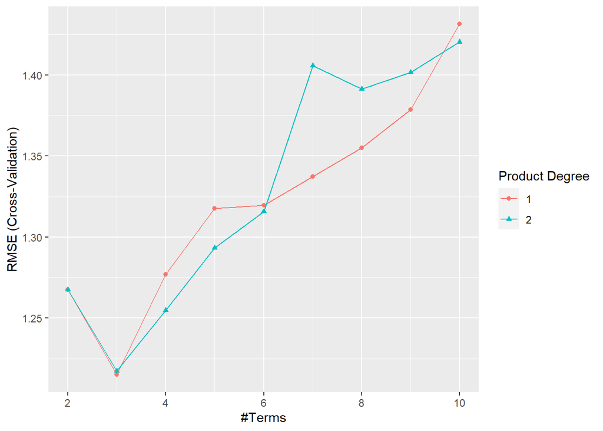

```r
ggplot(mars_chem_model)
```

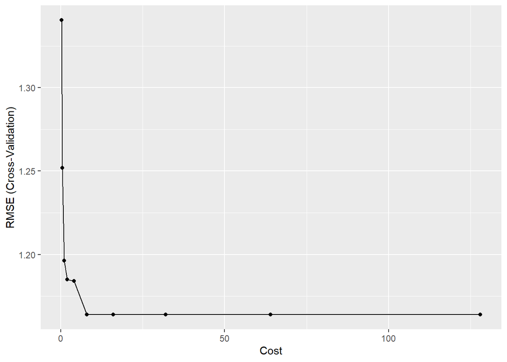

```r
ggplot(svm_chem_model)
```

The SVM model performs slightly better in the cross-validation and on the test set.

Part B

Which predictors are most important in the optimal nonlinear regression model? Do either the biological or process variables dominate the list? How do the top ten important predictors compare to the top ten predictors from the optimal linear model?

```r
varImp(mars_chem_model)
```

```
## earth variable importance
##
##                        Overall
## ManufacturingProcess32     100
## ManufacturingProcess13       0
```

```r
varImp(svm_chem_model)
```

```
## loess r-squared variable importance
##
##   only 20 most important variables shown (out of 48)
##
##                        Overall
## ManufacturingProcess32  100.00
## ManufacturingProcess36   69.14
## BiologicalMaterial06     67.36
## BiologicalMaterial03     52.42
## ManufacturingProcess13   46.88
## BiologicalMaterial04     45.20
## ManufacturingProcess02   43.43
## ManufacturingProcess33   40.84
## ManufacturingProcess06   39.65
## BiologicalMaterial01     39.38
## BiologicalMaterial08     36.92
## BiologicalMaterial11     35.61
## ManufacturingProcess26   34.84
## ManufacturingProcess17   29.79
## ManufacturingProcess09   26.82
## ManufacturingProcess04   25.56
## ManufacturingProcess15   23.90
## ManufacturingProcess28   23.72
## ManufacturingProcess19   21.86
## BiologicalMaterial10     21.85
```

Part C

Explore the relationships between the top predictors and the response for the predictors that are unique to the optimal nonlinear regression model. Do these plots reveal intuition about the biological or process predictors and their relationship with yield?

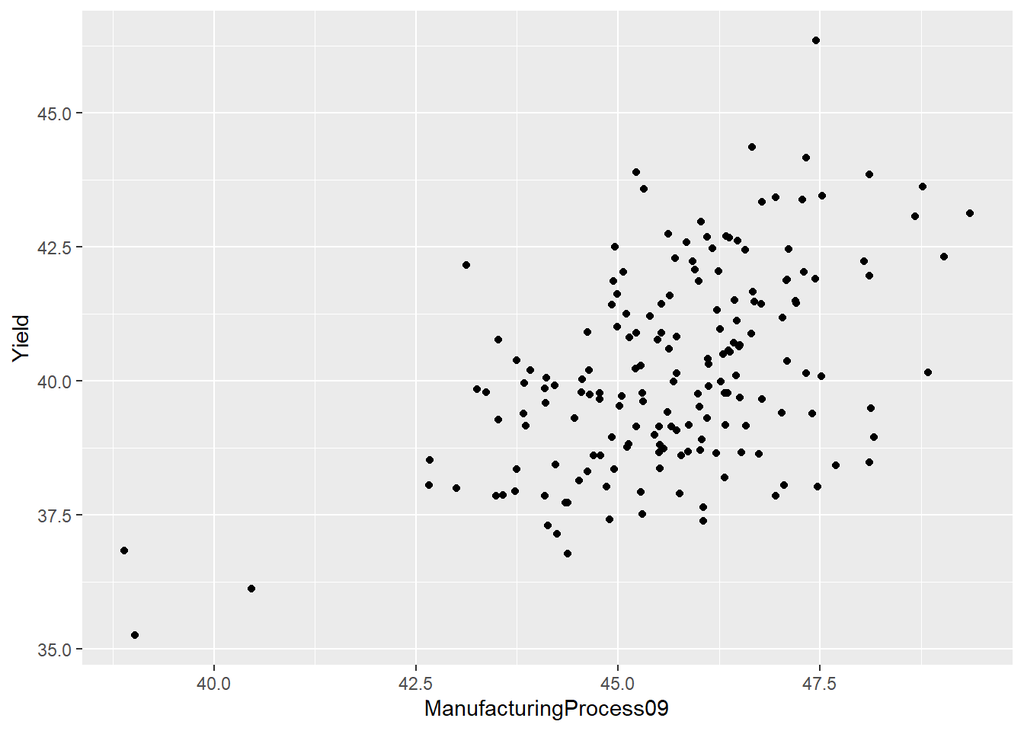

```r
ggplot(ChemicalManufacturingProcess, aes(x=ManufacturingProcess09, y=Yield)) + geom_point()
```

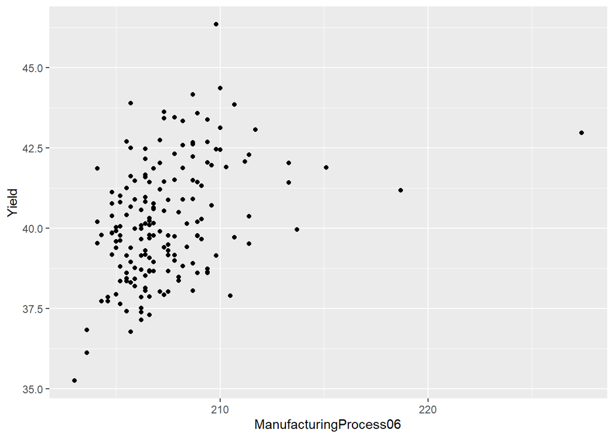

```r
ggplot(ChemicalManufacturingProcess, aes(x=ManufacturingProcess06, y=Yield)) + geom_point()
```

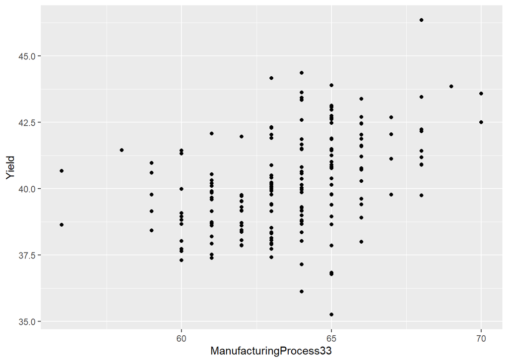

```r
ggplot(ChemicalManufacturingProcess, aes(x=ManufacturingProcess33, y=Yield)) + geom_point()
```

# Resources

https://bradleyboehmke.github.io/HOML/mars.html#mars-features